# Week 2 discussion

# Week 2 Discussion: Cluster Analysis on White Wine Data

### *Key takeaways are provided in the discussion submission text box in Canvas.*

### 1. Import the dataset into R

```r
#install.packages("NbClust")
#install.packages("factoextra")

library(cluster)
library(NbClust)
library(factoextra)
wine <- read.table("C:/Users/bae96639/Desktop/Uploads/winequality-white(UCI).csv",sep=";",header = T)
head(wine)
```

```
##   fixed.acidity volatile.acidity citric.acid residual.sugar chlorides
## 1           7.0             0.27        0.36           20.7     0.045
## 2           6.3             0.30        0.34            1.6     0.049
## 3           8.1             0.28        0.40            6.9     0.050
## 4           7.2             0.23        0.32            8.5     0.058
## 5           7.2             0.23        0.32            8.5     0.058
## 6           8.1             0.28        0.40            6.9     0.050
##   free.sulfur.dioxide total.sulfur.dioxide density   pH sulphates alcohol
## 1                  45                  170  1.0010 3.00      0.45     8.8
## 2                  14                  132  0.9940 3.30      0.49     9.5
## 3                  30                   97  0.9951 3.26      0.44    10.1
## 4                  47                  186  0.9956 3.19      0.40     9.9
## 5                  47                  186  0.9956 3.19      0.40     9.9
## 6                  30                   97  0.9951 3.26      0.44    10.1
##   quality
## 1       6
## 2       6
## 3       6
## 4       6
## 5       6
## 6       6
```

### 2. Examine and demonstrate the data structure

### 3. Check some basic info about the variables

```r
names(wine)
```

```
##  [1] "fixed.acidity"        "volatile.acidity"     "citric.acid"
##  [4] "residual.sugar"       "chlorides"            "free.sulfur.dioxide"
##  [7] "total.sulfur.dioxide" "density"              "pH"
## [10] "sulphates"            "alcohol"              "quality"
```

```r
summary(wine)
```

```
##  fixed.acidity    volatile.acidity  citric.acid     residual.sugar
##  Min.   : 3.800   Min.   :0.0800   Min.   :0.0000   Min.   : 0.600
##  1st Qu.: 6.300   1st Qu.:0.2100   1st Qu.:0.2700   1st Qu.: 1.700
##  Median : 6.800   Median :0.2600   Median :0.3200   Median : 5.200
##  Mean   : 6.855   Mean   :0.2782   Mean   :0.3342   Mean   : 6.391
##  3rd Qu.: 7.300   3rd Qu.:0.3200   3rd Qu.:0.3900   3rd Qu.: 9.900
##  Max.   :14.200   Max.   :1.1000   Max.   :1.6600   Max.   :65.800
##    chlorides       free.sulfur.dioxide total.sulfur.dioxide    density
##  Min.   :0.00900   Min.   :  2.00      Min.   :  9.0        Min.   :0.9871
##  1st Qu.:0.03600   1st Qu.: 23.00      1st Qu.:108.0        1st Qu.:0.9917
##  Median :0.04300   Median : 34.00      Median :134.0        Median :0.9937
##  Mean   :0.04577   Mean   : 35.31      Mean   :138.4        Mean   :0.9940
##  3rd Qu.:0.05000   3rd Qu.: 46.00      3rd Qu.:167.0        3rd Qu.:0.9961
##  Max.   :0.34600   Max.   :289.00      Max.   :440.0        Max.   :1.0390
##        pH          sulphates         alcohol         quality
##  Min.   :2.720   Min.   :0.2200   Min.   : 8.00   Min.   :3.000
##  1st Qu.:3.090   1st Qu.:0.4100   1st Qu.: 9.50   1st Qu.:5.000
##  Median :3.180   Median :0.4700   Median :10.40   Median :6.000
##  Mean   :3.188   Mean   :0.4898   Mean   :10.51   Mean   :5.878
##  3rd Qu.:3.280   3rd Qu.:0.5500   3rd Qu.:11.40   3rd Qu.:6.000
##  Max.   :3.820   Max.   :1.0800   Max.   :14.20   Max.   :9.000
```

```r
str(wine)
```

```
## 'data.frame':    4898 obs. of  12 variables:
##  $ fixed.acidity       : num  7 6.3 8.1 7.2 7.2 8.1 6.2 7 6.3 8.1 ...
##  $ volatile.acidity    : num  0.27 0.3 0.28 0.23 0.23 0.28 0.32 0.27 0.3 0.22 ...
##  $ citric.acid         : num  0.36 0.34 0.4 0.32 0.32 0.4 0.16 0.36 0.34 0.43 ...
##  $ residual.sugar      : num  20.7 1.6 6.9 8.5 8.5 6.9 7 20.7 1.6 1.5 ...
##  $ chlorides           : num  0.045 0.049 0.05 0.058 0.058 0.05 0.045 0.045 0.049 0.044 ...
##  $ free.sulfur.dioxide : num  45 14 30 47 47 30 30 45 14 28 ...
##  $ total.sulfur.dioxide: num  170 132 97 186 186 97 136 170 132 129 ...
##  $ density             : num  1.001 0.994 0.995 0.996 0.996 ...
##  $ pH                  : num  3 3.3 3.26 3.19 3.19 3.26 3.18 3 3.3 3.22 ...
##  $ sulphates           : num  0.45 0.49 0.44 0.4 0.4 0.44 0.47 0.45 0.49 0.45 ...
##  $ alcohol             : num  8.8 9.5 10.1 9.9 9.9 10.1 9.6 8.8 9.5 11 ...
##  $ quality             : int  6 6 6 6 6 6 6 6 6 6 ...
```

Removing the quality variable since this is our target variable for clustering:

```r
wine <- wine[,1:11]
names(wine)
```

```
##  [1] "fixed.acidity"        "volatile.acidity"     "citric.acid"
##  [4] "residual.sugar"       "chlorides"            "free.sulfur.dioxide"
##  [7] "total.sulfur.dioxide" "density"              "pH"
## [10] "sulphates"            "alcohol"
```

Standardize all the input variables:

```r
wine <-as.data.frame(scale(wine))
head(wine)
```

```
##   fixed.acidity volatile.acidity citric.acid residual.sugar   chlorides
## 1     0.1720794      -0.08176155  0.21325843      2.8210611 -0.03535139
## 2    -0.6574340       0.21587359  0.04799622     -0.9446688  0.14773200
## 3     1.4756004       0.01745016  0.54378284      0.1002720  0.19350284
## 4     0.4090832      -0.47860841 -0.11726599      0.4157258  0.55966962
## 5     0.4090832      -0.47860841 -0.11726599      0.4157258  0.55966962
## 6     1.4756004       0.01745016  0.54378284      0.1002720  0.19350284
##   free.sulfur.dioxide total.sulfur.dioxide      density          pH   sulphates
## 1           0.5698734            0.7444890  2.331273996 -1.24679399 -0.34914861
## 2          -1.2528907           -0.1496693 -0.009153237  0.73995309  0.00134171
## 3          -0.3121093           -0.9732363  0.358628185  0.47505348 -0.43677119
## 4           0.6874711            1.1209768  0.525801559  0.01147916 -0.78726151
## 5           0.6874711            1.1209768  0.525801559  0.01147916 -0.78726151
## 6          -0.3121093           -0.9732363  0.358628185  0.47505348 -0.43677119
##      alcohol
## 1 -1.3930102
## 2 -0.8241915
## 3 -0.3366326
## 4 -0.4991523
## 5 -0.4991523
## 6 -0.3366326
```

### 4. Use Hierarchical Clustering and Kmeans to cluster the wines. To do the analysis, make sure first find the “best” number of clusters. Also, make sure to try multiple linkage options. Then you can pick a preferred solution by studying the clusters’ patterns to make judgments.

KMN: Best # of clusters

```r
#the computer kept crashing so I reduced the max to 8 from 15
nbc<-NbClust(wine, min.nc=2, max.nc=8, method="kmeans")
```

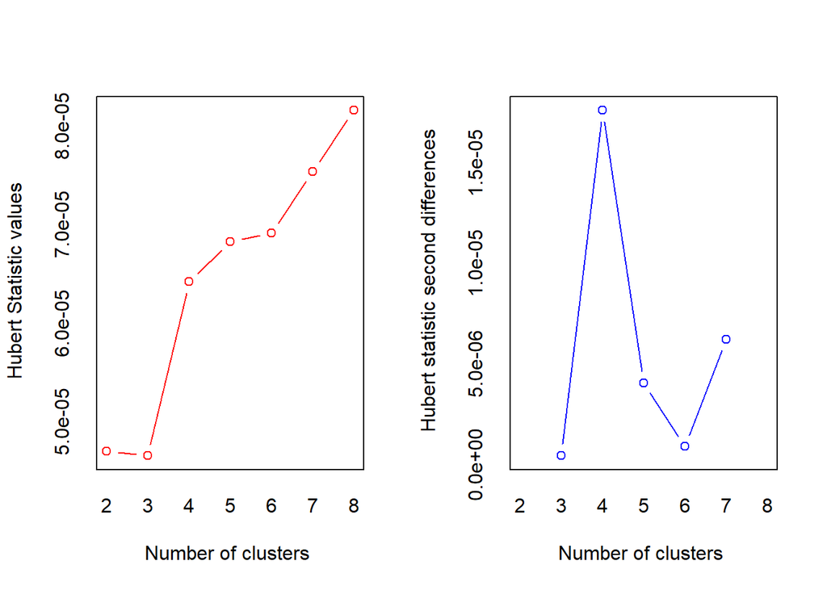

```
## *** : The Hubert index is a graphical method of determining the number of clusters.
##                 In the plot of Hubert index, we seek a significant knee that corresponds to a
##                 significant increase of the value of the measure i.e the significant peak in Hubert
##                 index second differences plot.
##
```

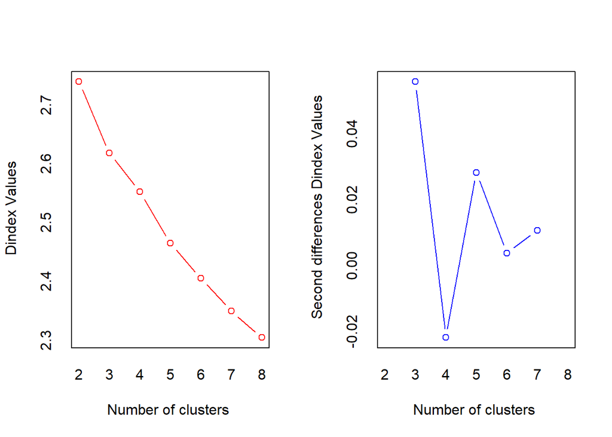

```
## *** : The D index is a graphical method of determining the number of clusters.
##                 In the plot of D index, we seek a significant knee (the significant peak in Dindex
##                 second differences plot) that corresponds to a significant increase of the value of
##                 the measure.
##
## * Among all indices:
## * 10 proposed 2 as the best number of clusters
## * 4 proposed 3 as the best number of clusters
## * 5 proposed 4 as the best number of clusters
## * 1 proposed 5 as the best number of clusters
## * 2 proposed 6 as the best number of clusters
## * 2 proposed 8 as the best number of clusters
##
##                    ***** Conclusion *****
##
## * According to the majority rule, the best number of clusters is  2
##
##
```

```r
nbc
```

```
## $All.index
##       KL        CH Hartigan      CCC     Scott      Marriot   TrCovW   TraceW
## 2 9.9591 1303.6490 436.8675  -3.7107  6378.226 2.628149e+38 19584072 42539.96
## 3 0.4036  928.2305 418.4312 -10.4047  9643.513 3.036036e+38 15403632 39055.10
## 4 1.2169  811.0293 332.1863  -7.7788 15318.959 1.694164e+38 13508095 35979.52
## 5 1.3200  732.4561 264.2258  -4.2090 18284.119 1.444979e+38 11633460 33692.59
## 6 1.1380  670.3156 227.3771  -1.9703 20451.448 1.336756e+38 10043183 31966.38
## 7 1.2289  622.3285 192.8266  -0.0631 22356.872 1.233093e+38  9279010 30546.60
## 8 0.7832  581.8822 200.0384   2.7390 23783.992 1.203484e+38  8326618 29387.98
##   Friedman  Rubin Cindex     DB Silhouette   Duda   Pseudot2   Beale Ratkowsky
## 2  28.1254 1.2663 0.1403 1.9157     0.2145 1.4975 -1137.8678 -2.4723    0.2656
## 3  30.2018 1.3793 0.1355 2.2407     0.1447 0.8514   314.5579  1.2989    0.2749
## 4  33.3964 1.4972 0.1303 1.9138     0.1590 1.3703  -568.5950 -2.0107    0.2647
## 5  38.0323 1.5988 0.1262 1.8696     0.1437 7.8905 -1260.9941 -6.4404    0.2595
## 6  39.2517 1.6851 0.1225 1.7851     0.1460 3.4394  -365.2664 -5.2289    0.2523
```

[output cut: 169 more lines]

```
               ***** Conclusion *****
```

- According to the majority rule, the best number of clusters is 2

```r
set.seed(1234)
km<- kmeans(wine,2,nstart=25)

table(km$cluster)
```

```
##
##    1    2
## 1957 2941
```

```r
km$centers
```

```
##   fixed.acidity volatile.acidity citric.acid residual.sugar  chlorides
## 1     0.1758942       0.04687908   0.2342012      0.8479233  0.3983139
## 2    -0.1170435      -0.03119428  -0.1558422     -0.5642251 -0.2650460
##   free.sulfur.dioxide total.sulfur.dioxide    density         pH   sulphates
## 1           0.5972147            0.7656087  0.9473672 -0.2015099  0.05986124
## 2          -0.3973986           -0.5094513 -0.6303970  0.1340887 -0.03983286
##      alcohol
## 1 -0.7907243
## 2  0.5261637
```

KMN: Merge cluster ID to the original dataset:

```r
wine_kmn<-as.data.frame(cbind(wine, km$cluster))
colnames(wine_kmn)[12]<-"clusters"

wine_kmn <- wine_kmn[,1:12] #to remove the additional km$cluster column
names(wine_kmn)
```

```
##  [1] "fixed.acidity"        "volatile.acidity"     "citric.acid"
##  [4] "residual.sugar"       "chlorides"            "free.sulfur.dioxide"
##  [7] "total.sulfur.dioxide" "density"              "pH"
## [10] "sulphates"            "alcohol"              "clusters"
```

KMN: Group means by each cluster

```r
aggregate(wine_kmn[1:11], by=list(wine_kmn$clusters), FUN=mean)
```

```
##   Group.1 fixed.acidity volatile.acidity citric.acid residual.sugar  chlorides
## 1       1     0.1758942       0.04687908   0.2342012      0.8479233  0.3983139
## 2       2    -0.1170435      -0.03119428  -0.1558422     -0.5642251 -0.2650460
##   free.sulfur.dioxide total.sulfur.dioxide    density         pH   sulphates
## 1           0.5972147            0.7656087  0.9473672 -0.2015099  0.05986124
## 2          -0.3973986           -0.5094513 -0.6303970  0.1340887 -0.03983286
##      alcohol
## 1 -0.7907243
## 2  0.5261637
```

KMN: Visualized

```r
library(factoextra)
set.seed(1234)
km.res <- eclust(wine_kmn, "kmeans", k = 2, nstart = 25, graph = FALSE)

table(km.res$cluster)
```

```
##
##    1    2
## 1957 2941
```

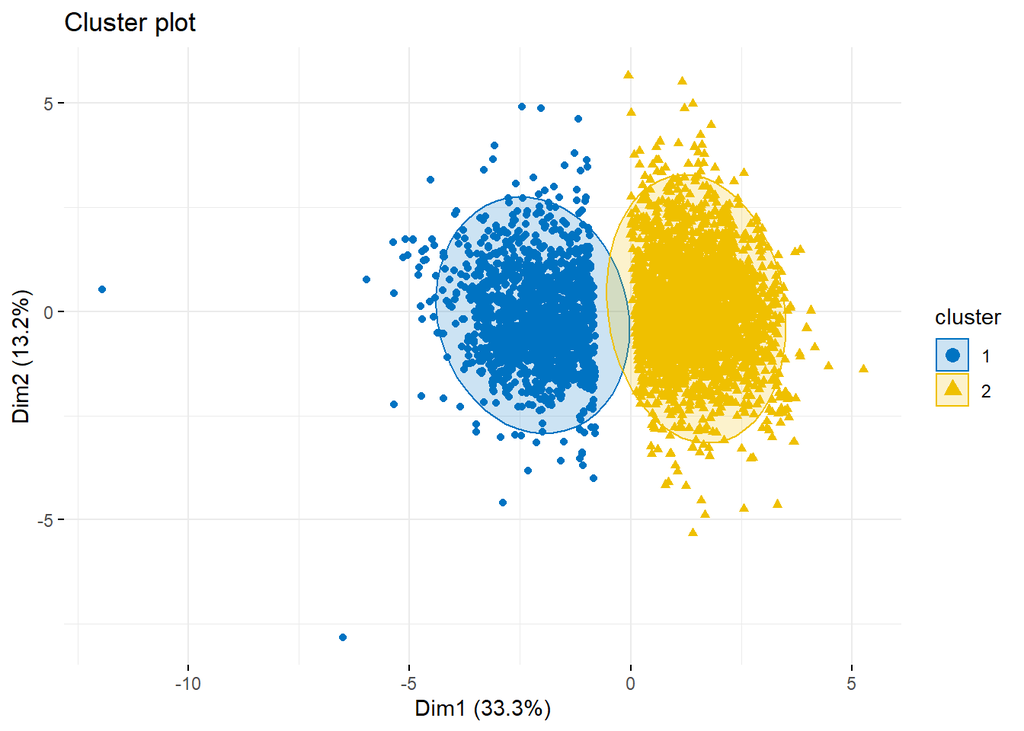

```r
fviz_cluster(km.res, geom = "point", ellipse.type = "norm",
             palette = "jco", ggtheme = theme_minimal())
```

Hierarchical Clustering: Best # of clusters w/ complete linkage approach

```r
numComplete <- NbClust(wine, distance="euclidean", min.nc=2, max.nc=10,
                       method="complete", index="all")
```

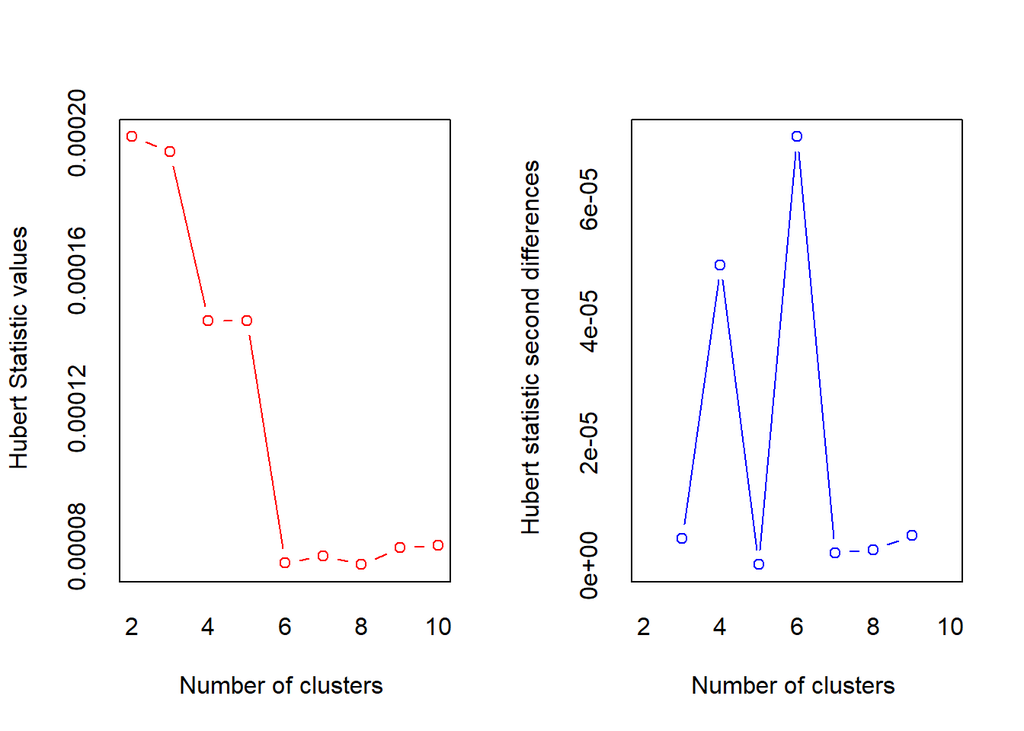

```
## *** : The Hubert index is a graphical method of determining the number of clusters.
##                 In the plot of Hubert index, we seek a significant knee that corresponds to a
##                 significant increase of the value of the measure i.e the significant peak in Hubert
##                 index second differences plot.
##
```

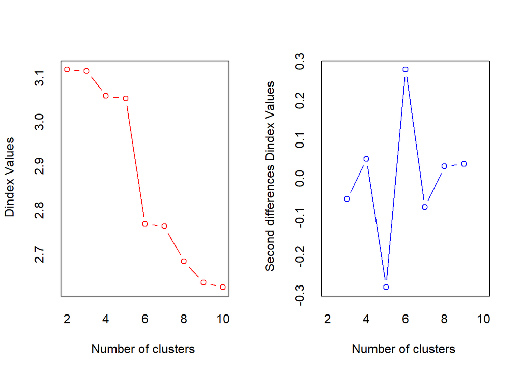

```
## *** : The D index is a graphical method of determining the number of clusters.
##                 In the plot of D index, we seek a significant knee (the significant peak in Dindex
##                 second differences plot) that corresponds to a significant increase of the value of
##                 the measure.
##
## * Among all indices:
## * 9 proposed 2 as the best number of clusters
## * 5 proposed 3 as the best number of clusters
## * 2 proposed 4 as the best number of clusters
## * 1 proposed 5 as the best number of clusters
## * 6 proposed 6 as the best number of clusters
## * 1 proposed 9 as the best number of clusters
##
##                    ***** Conclusion *****
##
## * According to the majority rule, the best number of clusters is  2
##
##
```

```
               ***** Conclusion *****
```

- According to the majority rule, the best number of clusters is 2

```r
names(numComplete)
```

```
## [1] "All.index"          "All.CriticalValues" "Best.nc"
## [4] "Best.partition"
```

```r
#see all indices
numComplete$Best.nc
```

```
##                      KL       CH Hartigan      CCC    Scott      Marriot
## Number_clusters  3.0000   6.0000   6.0000   2.0000    4.000 4.000000e+00
## Value_Index     15.5755 285.6153 938.3916 -72.8423 4390.602 7.980441e+38
##                   TrCovW   TraceW Friedman   Rubin Cindex   DB Silhouette
## Number_clusters        6    6.000   6.0000  6.0000 2.0000 2.00     2.0000
## Value_Index     14372647 7997.688  31.0324 -0.2057 0.2099 0.16     0.7869
##                   Duda PseudoT2 Beale Ratkowsky     Ball PtBiserial     Frey
## Number_clusters 2.0000   2.0000 2.000    9.0000    3.000     5.0000   3.0000
## Value_Index     0.9999   0.6564 0.001    0.1728 8999.946     0.4459 108.3824
##                 McClain  Dunn Hubert SDindex Dindex   SDbw
## Number_clusters   2e+00 2.000      0  3.0000      0 3.0000
## Value_Index       1e-04 0.676      0  0.4973      0 0.3292
```

Hierarchical Clustering: Calculate distance matrix

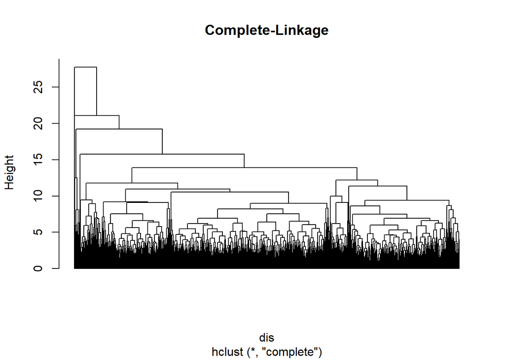

```r
dis <- dist(wine, method="euclidean")

hc <- hclust(dis, method="complete")

plot(hc, hang=-1,labels=FALSE, main="Complete-Linkage")
```

HC: Cut into 2 clusters

```r
comp2 <- cutree(hc, 2)

table(comp2)
```

```
## comp2
##    1    2
## 4897    1
```

HC: The second cluster is way too small

Average in lieue of Complete linkage:

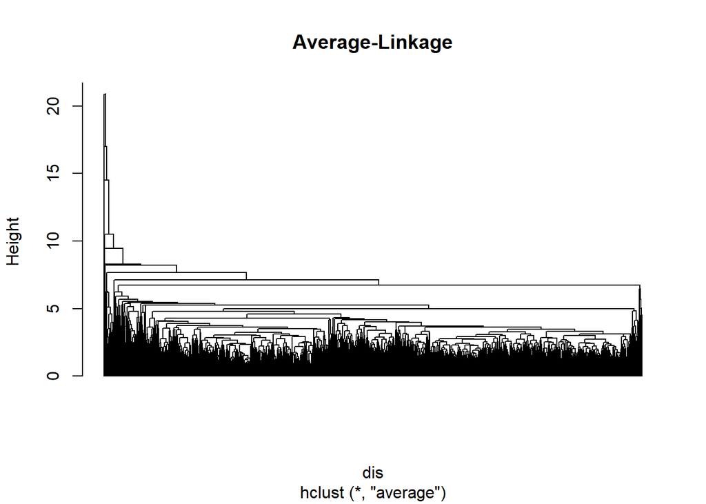

```r
hc2 <- hclust(dis, method="average")
plot(hc2, hang=-1,labels=FALSE, main="Average-Linkage")
```

```r
comp2 <- cutree(hc2, 2)
table(comp2)
```

```
## comp2
##    1    2
## 4897    1
```

HC: Still uneven clusters, now I’ll try the Ward method

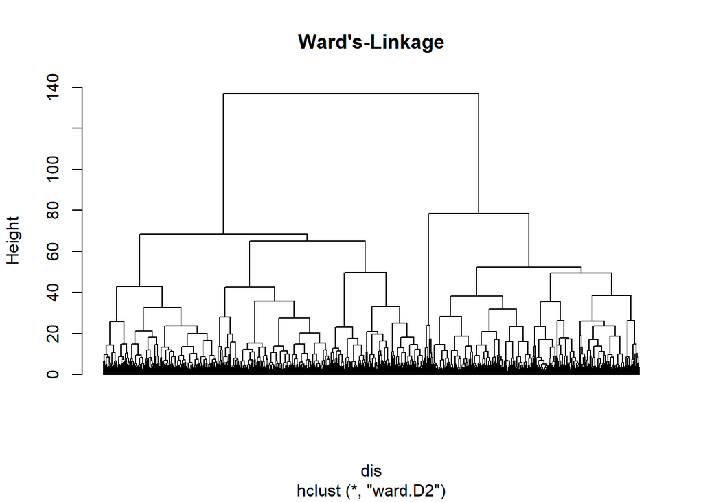

```r
hc3 <- hclust(dis, method="ward.D2")
plot(hc3, hang=-1,labels=FALSE, main="Ward's-Linkage")
```

```r
comp2 <- cutree(hc3, 2)
table(comp2)
```

```
## comp2
##    1    2
## 1965 2933
```

```r
#double-checking my work since cluster # exploration was originally done with complete linkage in mind
numComplete <- NbClust(wine, distance="euclidean", min.nc=2, max.nc=10,
                       method="ward.D2", index="all")
```

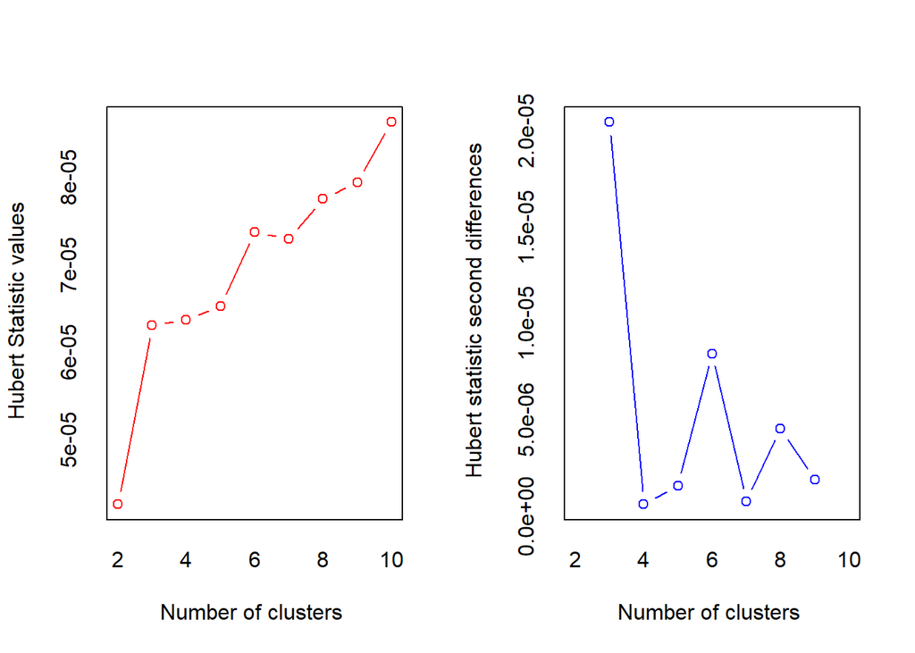

```
## *** : The Hubert index is a graphical method of determining the number of clusters.
##                 In the plot of Hubert index, we seek a significant knee that corresponds to a
##                 significant increase of the value of the measure i.e the significant peak in Hubert
##                 index second differences plot.
##
```

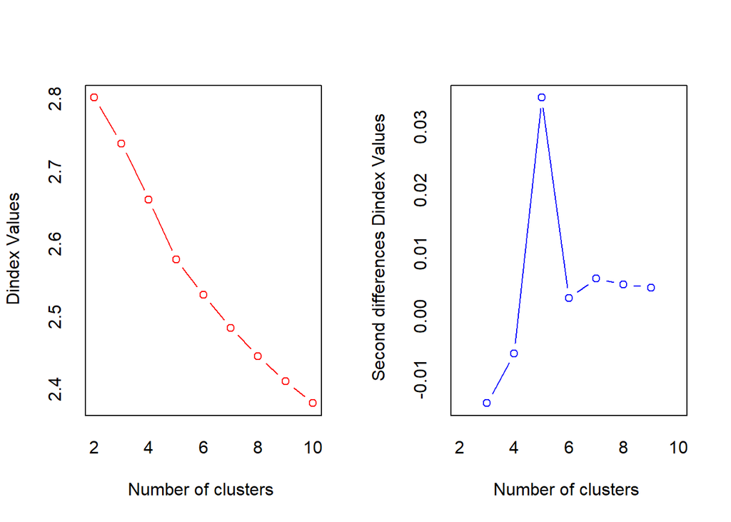

```
## *** : The D index is a graphical method of determining the number of clusters.
##                 In the plot of D index, we seek a significant knee (the significant peak in Dindex
##                 second differences plot) that corresponds to a significant increase of the value of
##                 the measure.
##
## * Among all indices:
## * 6 proposed 2 as the best number of clusters
## * 6 proposed 3 as the best number of clusters
## * 2 proposed 4 as the best number of clusters
## * 6 proposed 5 as the best number of clusters
## * 1 proposed 7 as the best number of clusters
## * 1 proposed 8 as the best number of clusters
## * 1 proposed 9 as the best number of clusters
##
##                    ***** Conclusion *****
##
## * According to the majority rule, the best number of clusters is  2
##
##
```

```
               ***** Conclusion *****
```

- According to the majority rule, the best number of clusters is 2

### 5. Demonstrate each cluster’s characteristics. Do some comparisons between clusters and know more about the profiles about each cluster. Graph the differences to make the patterns more visually friendly

```r
#aggregate first
wine_hc_mean <- aggregate(wine, by=list(comp2), FUN=mean)
wine_hc_mean
```

```
##   Group.1 fixed.acidity volatile.acidity citric.acid residual.sugar  chlorides
## 1       1    0.07863475      -0.06931591   0.2565294       0.835187  0.3220572
## 2       2   -0.05268234       0.04643906  -0.1718651      -0.559544 -0.2157662
##   free.sulfur.dioxide total.sulfur.dioxide    density         pH   sulphates
## 1           0.6049582            0.6626413  0.8337621 -0.2064732  0.01877704
## 2          -0.4052993           -0.4439448 -0.5585894  0.1383293 -0.01257991
##      alcohol
## 1 -0.6532909
## 2  0.4376804
```

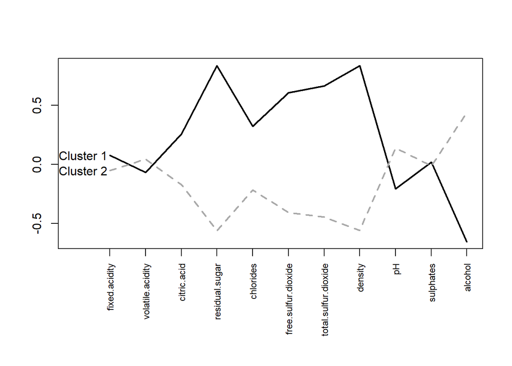

```r
cluster_viz <- function(cluster_stat, features) {

  row.names(cluster_stat) = cluster_stat$Group.1
  cluster_stat <- cluster_stat[,-1]
  par(mar=c(8,4,4,2))
  plot(c(0), xaxt="n", xlab="", ylab="", type="l",
       ylim=c(min(cluster_stat), max(cluster_stat)),
       xlim=c(0,ncol(features)))
  axis(1, at=c(1:ncol(features)), labels=names(features), las=2, cex.axis=0.75)
  nbr_clusters = nrow(cluster_stat)
  for(i in 1:nbr_clusters) {
    lines(as.matrix(cluster_stat)[i,],
          lty=i, lwd=2,
          col=ifelse(i %in% c(1, 3, 5), "black", "dark grey") )
  }
  text(x=0.25, y=cluster_stat[,1], labels=paste("Cluster", c(1:nbr_clusters)))
}
cluster_viz(wine_hc_mean, wine)
```

When settling on what would be the best way to convey the many relationships between both clusters, I saw this method posted on the discussion and enjoyed how effective it was at getting the point across, so I applied it to my own code

### 6. Pick at least two variables and cut them into groups and convert them into factor variables (rather than the original continuous variables). It then becomes a mixed dataset with both numeric and categorical variables.

I’ve chosen sulphates and alcohol content for my analysis

```r
mean(wine$sulphates)
```

```
## [1] 1.50847e-16
```

```r
median(wine$sulphates)
```

```
## [1] -0.1739035
```

```r
min(wine$sulphates)
```

```
## [1] -2.364468
```

```r
max(wine$sulphates)
```

```
## [1] 5.171074
```

```r
mean(wine$alcohol)
```

```
## [1] -3.73879e-16
```

```r
median(wine$alcohol)
```

```
## [1] -0.09285319
```

```r
min(wine$alcohol)
```

```
## [1] -2.043089
```

```r
max(wine$alcohol)
```

```
## [1] 2.99502
```

```r
wine$sulphates = as.factor(ifelse(wine$sulphates>0, "High", "Low"))
wine$alcohol = as.factor(ifelse(wine$alcohol>0, "High", "Low"))

table(wine$sulphates)
```

```
##
## High  Low
## 2265 2633
```

```r
str(wine$sulphates)
```

```
##  Factor w/ 2 levels "High","Low": 2 1 2 2 2 2 2 2 1 2 ...
```

```r
table(wine$alcohol)
```

```
##
## High  Low
## 2163 2735
```

```r
str(wine$alcohol)
```

```
##  Factor w/ 2 levels "High","Low": 2 2 2 2 2 2 2 2 2 1 ...
```

### 7. Use “daisy()” function to calculate the distance and use “pam()” function to do the cluster analysis. You can also use “Silhouette” approach to determine the “best” number of clusters.

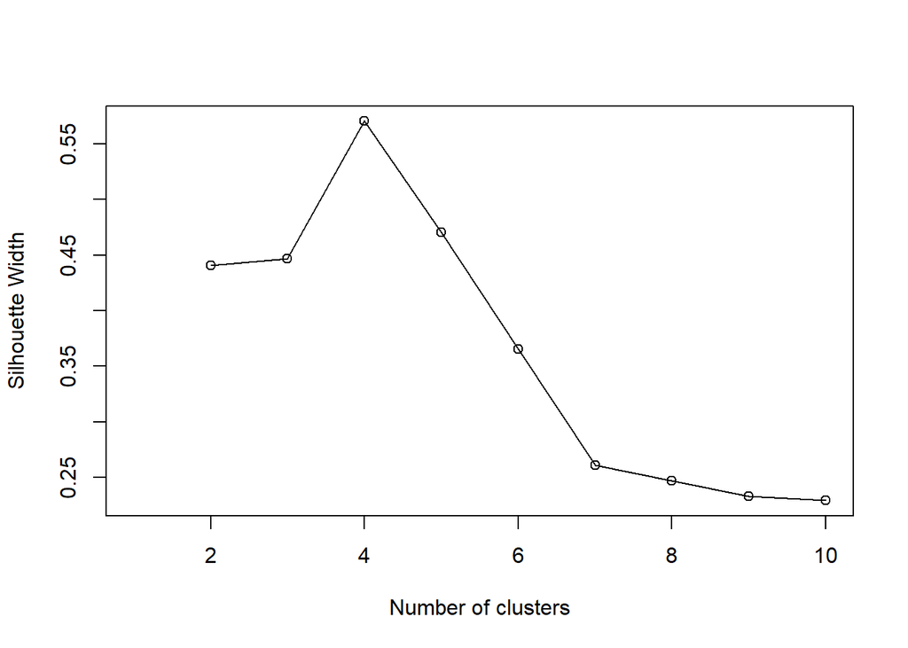

```r
disMat = daisy(wine, metric="gower")

sil_width <- c(NA)
for(i in 2:10){
  pam_fit <- pam(disMat, diss = TRUE, k = i)
  sil_width[i] <- pam_fit$silinfo$avg.width
}

plot(1:10, sil_width,
     xlab = "Number of clusters",
     ylab = "Silhouette Width")
lines(1:10, sil_width)
```

### 8. Then, demonstrate each cluster’s characteristics. Conduct some comparisons between clusters and know more about the profile about each cluster. Graph the differences to make the patterns more visually friendly

```r
set.seed(123)
pamFit <- pam(disMat, k=4)
table(pamFit$clustering)
```

```
##
##    1    2    3    4
## 1395 1340 1238  925
```

```r
#install.packages("compareGroups")

library(compareGroups)
wine_final<-as.data.frame(cbind(wine, pamFit$clustering))
colnames(wine_final)[12]<-"clusters"

group <- compareGroups(clusters~., data=wine_final)
```

Visualize:

```r
p<-table(wine_final$sulphates,wine_final$clusters)
p
```

```
##
##           1    2    3    4
##   High    0 1340    0  925
##   Low  1395    0 1238    0
```

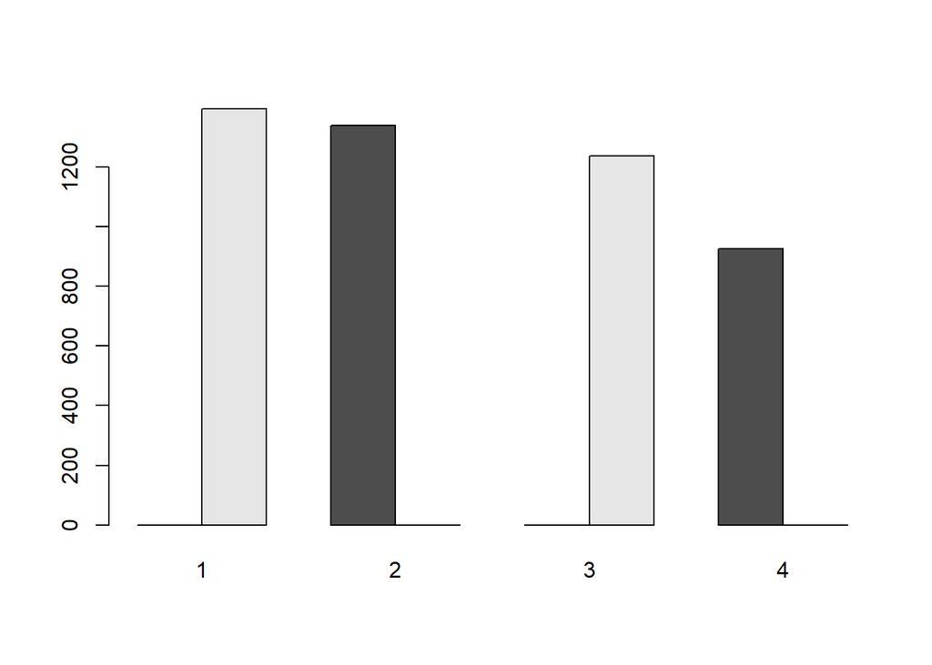

```r
barplot(p,beside=TRUE)
```

```r
p2<-table(wine_final$alcohol,wine_final$clusters)
p2
```

```
##
##           1    2    3    4
##   High    0    0 1238  925
##   Low  1395 1340    0    0
```

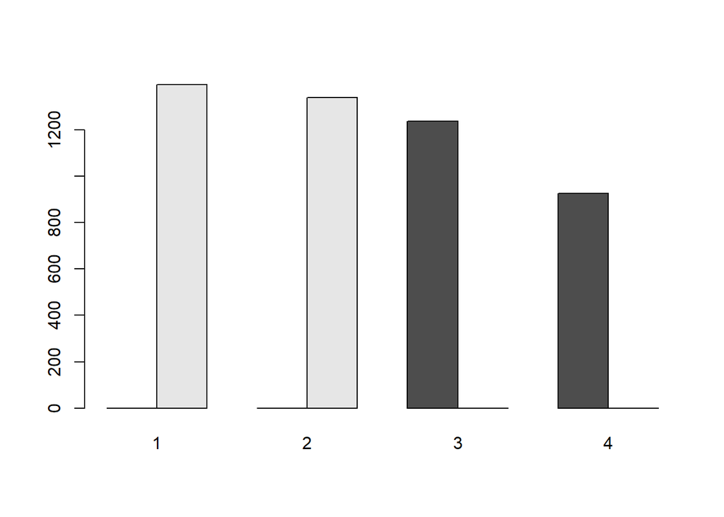

```r
barplot(p2,beside=TRUE)
```